# Chap 3: Customizing Traditional Graphics

jharner

February 4, 2015

## 3.5 Creating new plots

The `plot.new()` function is the most basic starting point for producing a traditional graphics plot (the `frame()` function is equivalent). This function starts a new plot and sets up the various plotting regions described in Section 3.1.1, with both the x-scale and y-scale set to (0,1). The size and position of the regions that are set up depend on the current graphics state settings.

The `plot.window()` function resets the scales in the user coordinate system, given x- and y-ranges via the arguments `xlim` and `ylim`, and the `plot.xy()` function draws data symbols and lines between locations within the plot region.

### 3.5.1 A simple plot from scratch

A scatterplot:

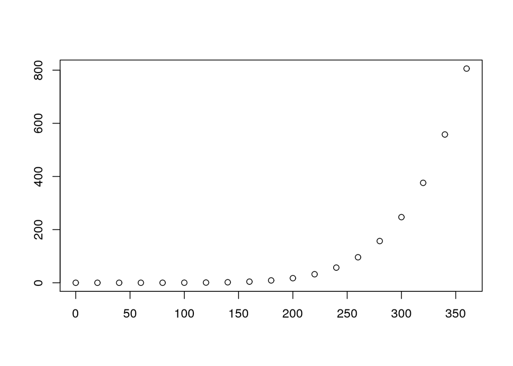

```r
plot.new()
plot.window(range(pressure$temperature), range(pressure$pressure))
plot.xy(pressure, type="p")
box()
axis(1)
axis(2)
```

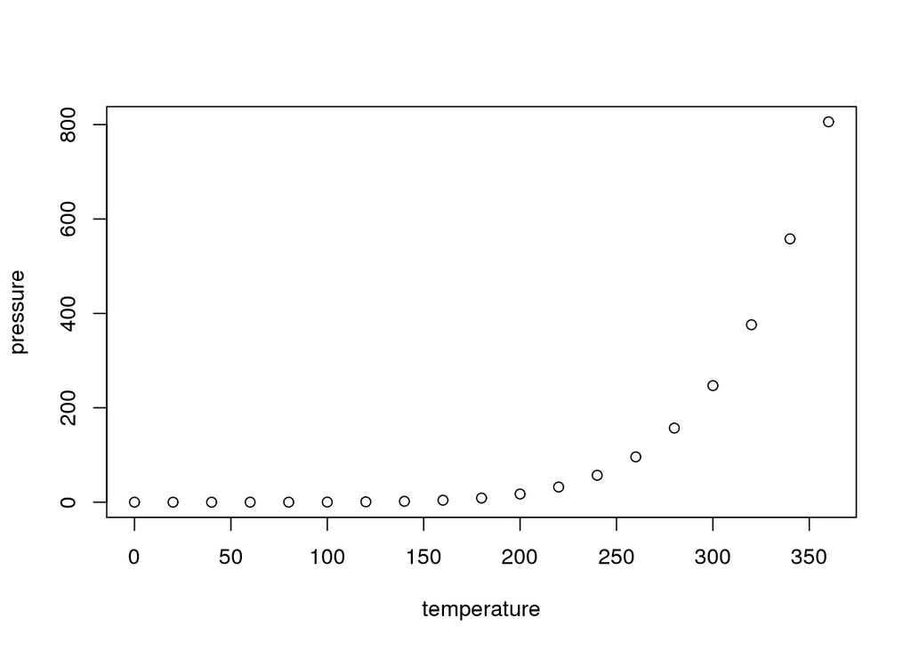

```r
plot(pressure)
```

The call to `plot.new()` starts a new, completely blank, plot and the call to `plot.window()` sets the scales on the axes to fit the range of the data to be plotted. At this point, there is still nothing drawn. The `plot.xy()` function draws data symbols (`type="p"`) at the data locations, then `box()` draws a rectangle around the plot region, and `axis()` is used to draw the axes.

### 3.5.2 A more complex plot from scratch

These are the counts of (adult) male and female survivors of the sinking of the Titanic.

```r
data(Titanic)
groups <- dimnames(Titanic)[[1]]
males <- Titanic[, 1, 2, 2]
males
```

```
##  1st  2nd  3rd Crew
##   57   14   75  192
```

```r
females <- Titanic[, 2, 2, 2]
females
```

```
##  1st  2nd  3rd Crew
##  140   80   76   20
```

The labels to the left of the plot will be drawn in the margins of the plot, but everything else will be drawn inside the plot region.

```r
y <- 1:4
h <- 0.2
```

This next code draws the main part of the plot. Everything is drawn using calls to the low-level functions such as lines(), segments(), mtext(), and axis().

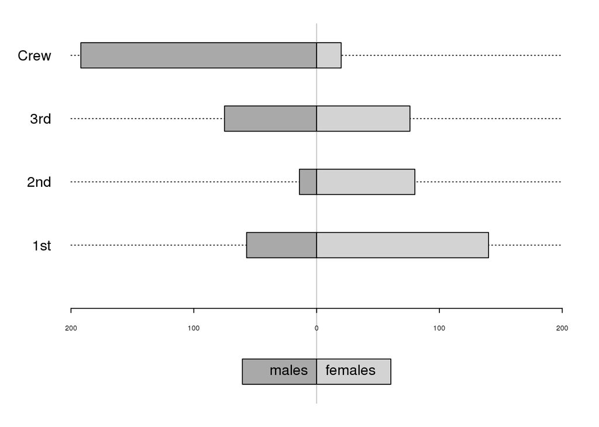

```r
par(mar=c(0.5, 3, 0.5, 1))
plot.new()
plot.window(xlim=c(-200, 200), ylim=c(-1.5, 4.5))
ticks <- seq(-200, 200, 100)
lines(rep(0, 2), c(-1.5, 4.5), col="gray")
segments(-200, y, 200, y, lty="dotted")
rect(-males, y-h, 0, y+h, col="dark gray")
rect(0, y-h, females, y+h, col="light gray")
mtext(groups, at=y, adj=1, side=2, las=2)
par(cex.axis=0.5, mex=0.5)
axis(1, at=ticks, labels=abs(ticks), pos=0)

# The final step is to produce the legend at the bottom of the plot.

tw <- 1.5*strwidth("females")
rect(-tw, -1-h, 0, -1+h, col="dark gray")
rect(0, -1-h, tw, -1+h, col="light gray")
text(0, -1, "males", pos=2)
text(0, -1, "females", pos=4)
```

### 3.5.3 Writing traditional graphics functions

This section briefly describes some of the things to consider when creating a new graphics function built on the traditional graphics system.

#### Helper functions

The `xy.coords()` function is useful for allowing x and y arguments to your new function to be flexibly specified.

Another set of useful helper functions are those that calculate values to plot from the raw data, but do no actual drawing, e.g., `boxplot.stats()` used by `boxplot()` to generate five-number summaries.

#### Argument lists

A common technique when writing a traditional graphics function is to provide an ellipsis argument (`...`) instead of individual graphics state arguments (such as `col` and `lty`). This allows users to specify any state settings.

It is polite for the graphics function to revert the graphics state settings at the end of the function so that users do not get a nasty surprise.

```
opar <- par(no.readonly=TRUE)
on.exit(par(opar))
```